# 02a_age_invariance

Vinay Tummarakota

2025-11-25

```r
df <- read.csv("../01_clean_data/cleaned_nlsy79_data.csv")
df <- df %>%
  filter(
    !is.na(estimated_age),
    !is.na(sampling_weight),
    if_all(starts_with("asvab"), ~ !is.na(.))
  )
```

## Choose Factor Structure

Before we can establish that the ASVAB g-factor is measurement invariant with respect to age, we must first establish which factor structure has sufficiently good fit to the data.

### Ree and Caretta (1995)

This model only yields a CFI of 0.905 and estimates the verbal/mathematical ability factor to have negative variance, so it does not have ideal fit to the data.

```r
ree_and_caretta_model <- '
  vm =~ asvab_section_2_arithmetic_reasoning
        + asvab_section_3_word_knowledge
        + asvab_section_4_paragraph_comprehension
        + asvab_section_8_mathematics_knowledge

  speed =~ asvab_section_5_numerical_operations
           + asvab_section_6_coding_speed

  tech =~ asvab_section_1_general_science
          + asvab_section_7_auto_and_shop_info
          + asvab_section_9_mechanical_comp
          + asvab_section_10_electronics_info

  g =~ vm + speed + tech

  vm ~~ 0*speed
  vm ~~ 0*tech
  speed ~~ 0*tech

  asvab_section_2_arithmetic_reasoning ~ 0*1
  asvab_section_5_numerical_operations ~ 0*1
  asvab_section_1_general_science ~ 0*1

  vm ~ 1
  speed ~ 1
  tech ~ 1
'

ree_and_caretta_fit <- cfa(
  data = df,
  model = ree_and_caretta_model,
  sampling.weights = "sampling_weight"
)

fitMeasures(ree_and_caretta_fit, "cfi")
```

```
##   cfi
## 0.905
```

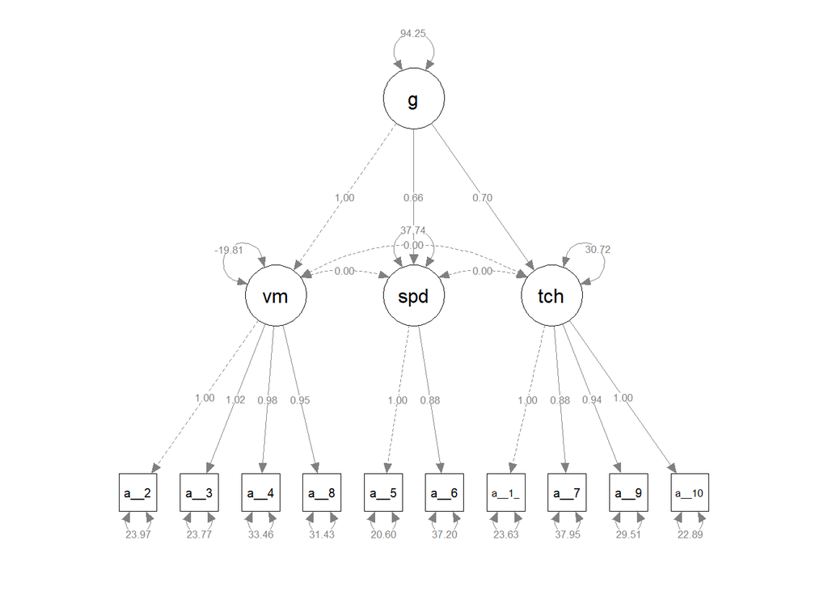

```r
semPaths(ree_and_caretta_fit, whatLabels = 'par', intercepts = FALSE)
```

#### Top 5 Modification Indices

```r
ree_and_caretta_modindices <- modindices(ree_and_caretta_fit, sort = TRUE, maximum.number = 5)
knitr::kable(head(ree_and_caretta_modindices))
```

|  | lhs | op | rhs | mi | epc | sepc.lv | sepc.all | sepc.nox |
| --- | --- | --- | --- | --- | --- | --- | --- | --- |
| 71 | g | =~ | asvab_section_1_general_science | 2860.418 | 0.4659575 | 4.523573 | 0.4504550 | 0.4504550 |
| 77 | asvab_section_2_arithmetic_reasoning | ~~ | asvab_section_8_mathematics_knowledge | 2633.736 | 16.8938384 | 16.893838 | 0.6155567 | 0.6155567 |
| 47 | vm | =~ | asvab_section_1_general_science | 2526.686 | 0.8566864 | 7.391184 | 0.7360103 | 0.7360103 |
| 84 | asvab_section_3_word_knowledge | ~~ | asvab_section_4_paragraph_comprehension | 1640.814 | 13.8662701 | 13.866270 | 0.4916606 | 0.4916606 |
| 72 | g | =~ | asvab_section_7_auto_and_shop_info | 1526.259 | -0.3605924 | -3.500676 | -0.3549041 | -0.3549041 |

### Deary et al (2007)

*Note*: I omitted the covariances between the (1) auto shop and mechanical tests (2) auto shop and math tests even though these covariances were kept in Deary et al.

```r
deary_et_al_model <- '
  vc =~ asvab_section_3_word_knowledge
        + asvab_section_4_paragraph_comprehension
        + asvab_section_1_general_science

  ar =~ asvab_section_2_arithmetic_reasoning
        + asvab_section_8_mathematics_knowledge

  ps =~ asvab_section_5_numerical_operations
       + asvab_section_6_coding_speed

  tk =~ asvab_section_7_auto_and_shop_info
       + asvab_section_9_mechanical_comp
       + asvab_section_10_electronics_info
       + asvab_section_1_general_science

  g =~ vc + ar + ps + tk

  vc ~~ 0*ar
  vc ~~ 0*ps
  vc ~~ 0*tk
  ar ~~ 0*ps
  ar ~~ 0*tk
  ps ~~ 0*tk

  asvab_section_3_word_knowledge ~ 0*1
  asvab_section_2_arithmetic_reasoning ~ 0*1
  asvab_section_5_numerical_operations ~ 0*1
  asvab_section_7_auto_and_shop_info ~ 0*1

  g ~ 1
'

deary_et_al_fit <- cfa(
  data = df,
  model = deary_et_al_model,
  sampling.weights = "sampling_weight"
)

fitMeasures(deary_et_al_fit, "cfi")
```

```
##   cfi
## 0.945
```

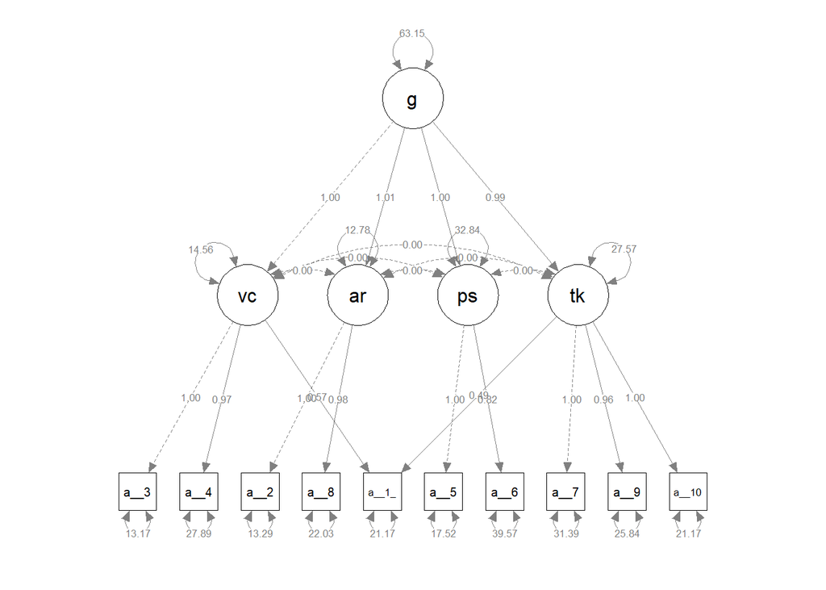

```r
semPaths(deary_et_al_fit, whatLabels = 'par', intercepts = FALSE)
```

#### Top 5 Modification Indices

```r
deary_et_al_modindices <- modindices(deary_et_al_fit, sort = TRUE, maximum.number = 5)
knitr::kable(head(deary_et_al_modindices))
```

|  | lhs | op | rhs | mi | epc | sepc.lv | sepc.all | sepc.nox |
| --- | --- | --- | --- | --- | --- | --- | --- | --- |
| 21 | ps | ~~ | tk | 1314.7603 | -17.7209435 | -0.5889351 | -0.5889351 | -0.5889351 |
| 64 | ar | =~ | asvab_section_7_auto_and_shop_info | 710.1711 | -0.3441891 | -3.0139304 | -0.2740943 | -0.2740943 |
| 123 | asvab_section_8_mathematics_knowledge | ~~ | asvab_section_7_auto_and_shop_info | 579.6234 | -7.6908181 | -7.6908181 | -0.2924817 | -0.2924817 |
| 139 | tk | ~~ | g | 570.2877 | -15.2816647 | -0.3662499 | -0.3662499 | -0.3662499 |
| 25 | asvab_section_7_auto_and_shop_info | ~1 |  | 570.2874 | 11.9112139 | 11.9112139 | 1.0832355 | 1.0832355 |

## Establish Measurement Invariance

To determine whether the ASVAB g-factor is measurement invariant with respect to age, we use Local Structural Equation Modeling (LSEM). LSEM suggests that the factor structure is materially different for 16 year olds: the arithmetic reasoning (ar) and technical knowledge (tk) factors have much weaker loadings on the general cognitive ability (g) factor in this age group.

```r
moderator.grid <- seq(16,23,1)

local_sem <- lsem.estimate(
  data = df,
  moderator="estimated_age",
  moderator.grid=moderator.grid,
  lavmodel=deary_et_al_model,
  h = 2,
  sampling_weights = df$sampling_weight
)
```

```
## ** Residualize Data
## ** Fit lavaan model
## |********|
## |--------|
## ** Parameter summary
```

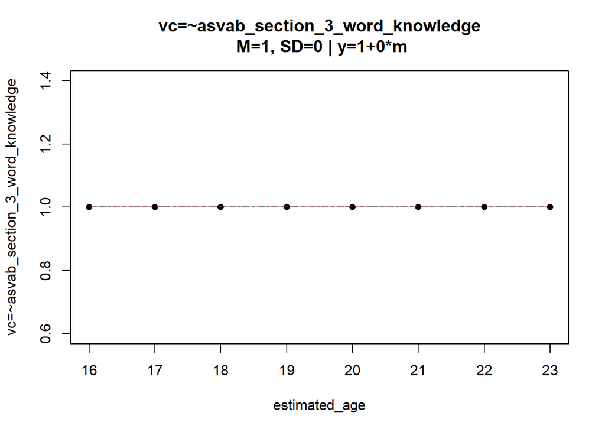

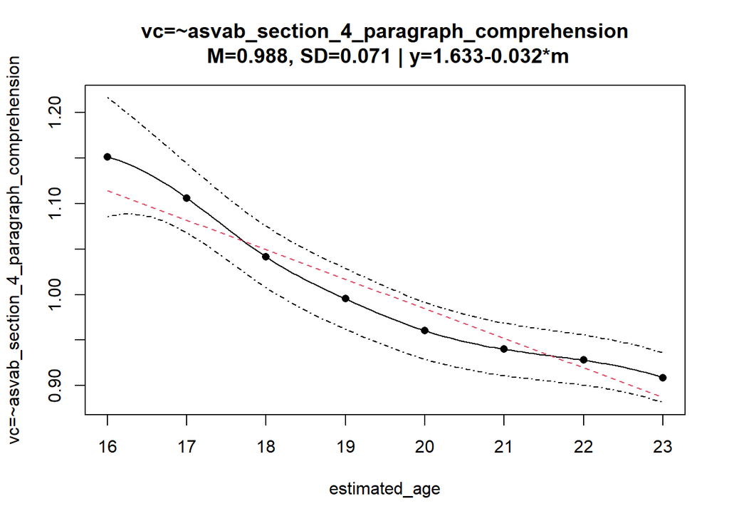

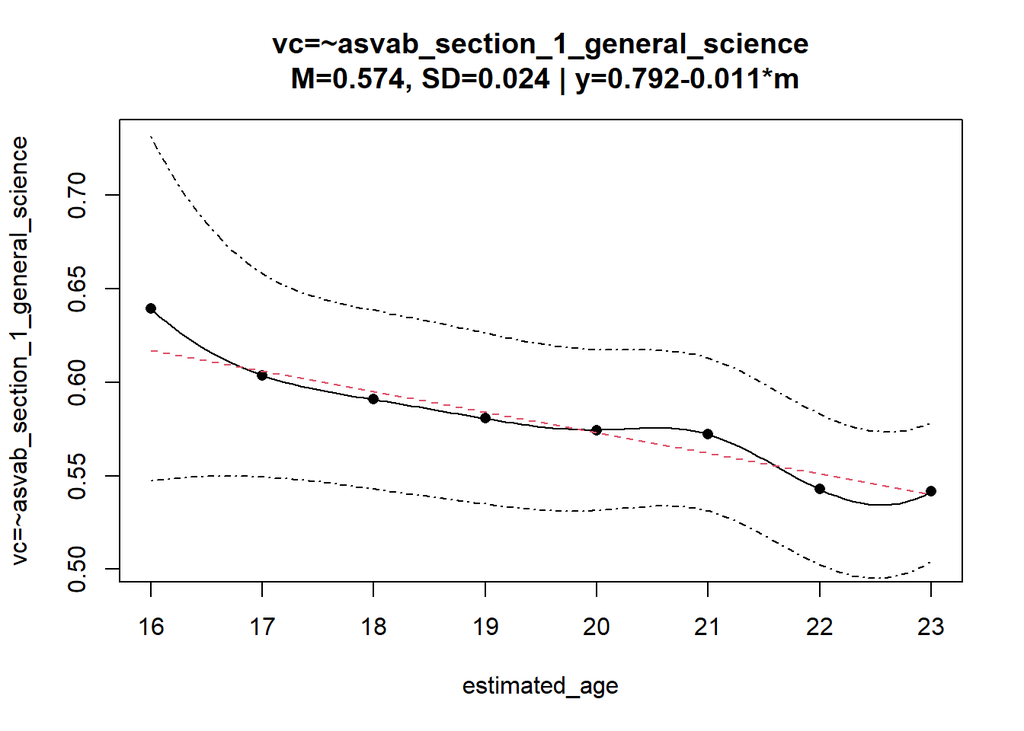

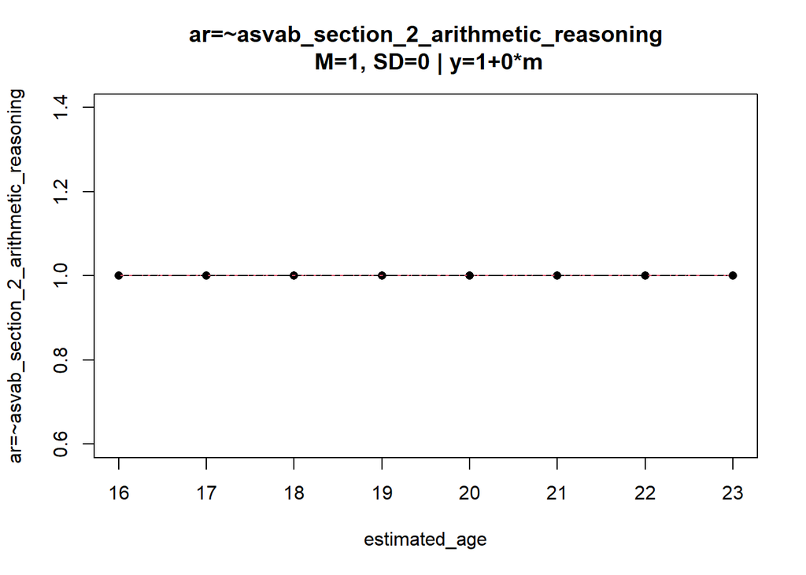

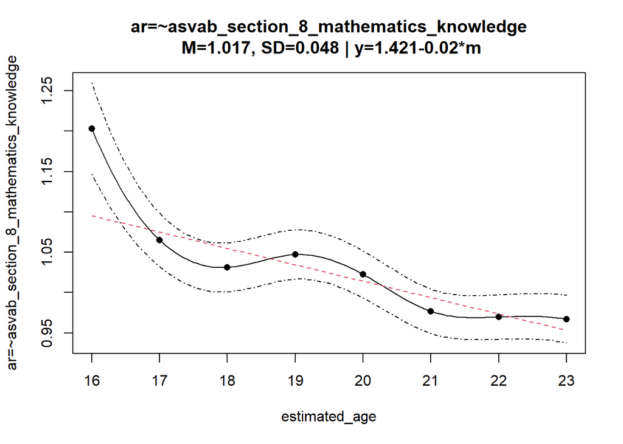

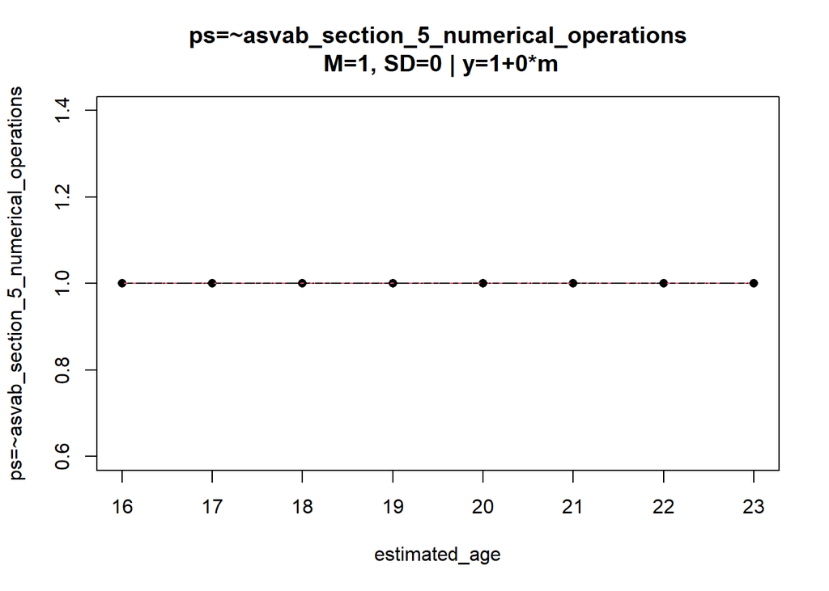

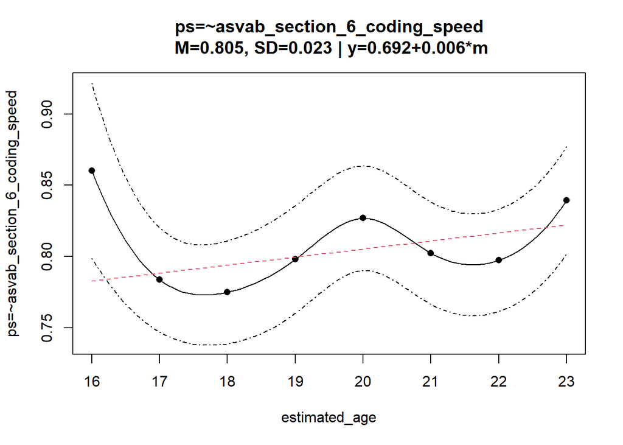

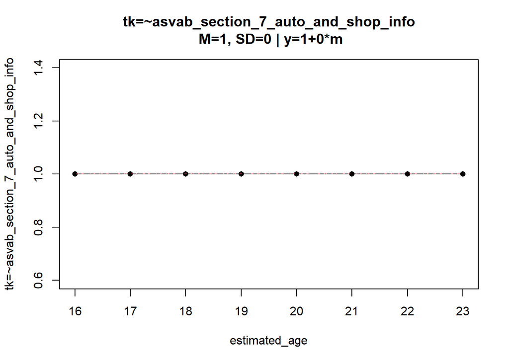

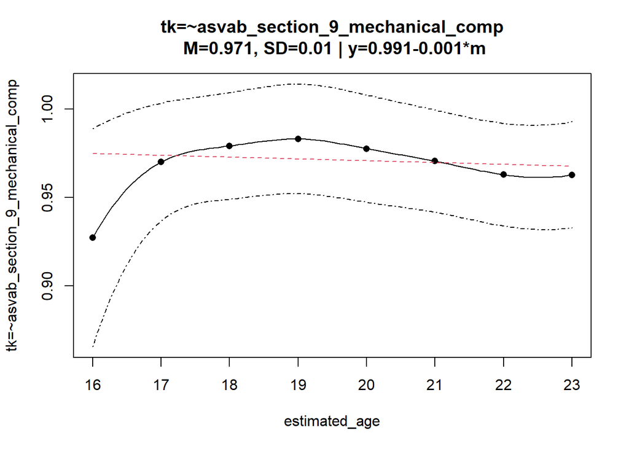

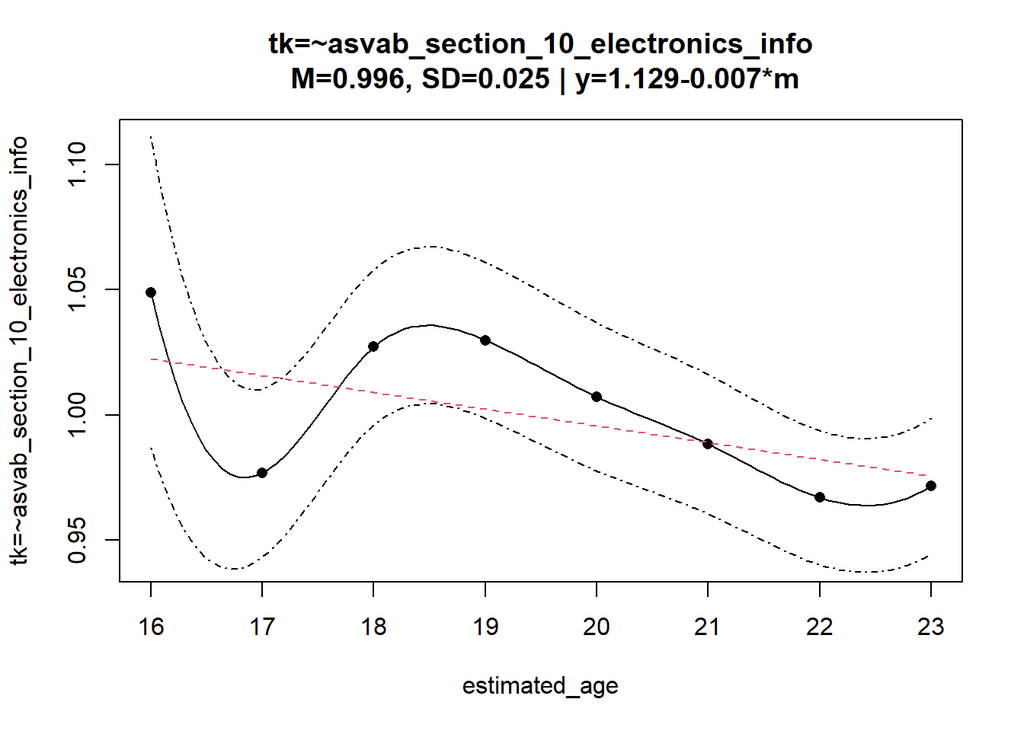

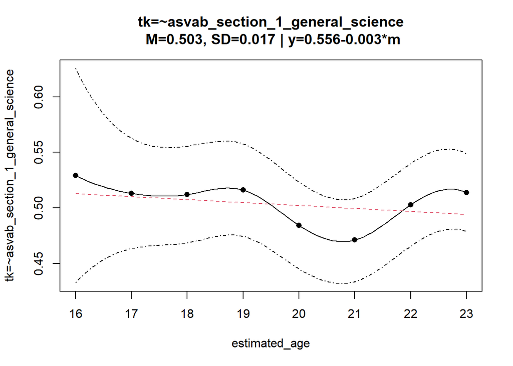

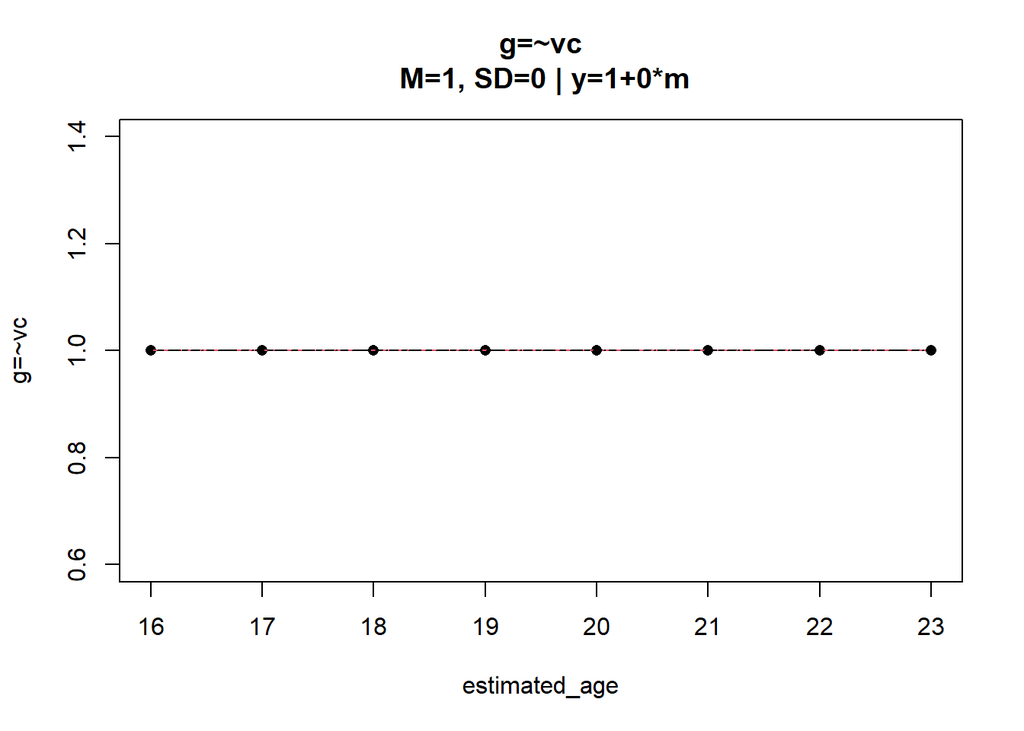

[39 more figures not shown]

```
## [1] NA
```

```r
# wrap the plotting function around tryCatch because it throws an error after plotting all parameters; I think it's a problem with the package
tryCatch(
  {
    plot(local_sem, ask = FALSE)
  },
  error = function(msg) {
    return(NA)
  }
)
```

To validate this qualitative finding, we can plot the correlation between g-factor scores from an LSEM where parameters area allowed to vary by age and an SEM where parameters are fixed across age group. This method is admittedly unorthodox, but I don’t think there is much consensus on establishing MI in the LSEM context.

```r
first_order_factors <- c("ar", "ps", "tk", "vc")
items <- c(
  "asvab_section_1_general_science",
  "asvab_section_2_arithmetic_reasoning",
  "asvab_section_3_word_knowledge",
  "asvab_section_4_paragraph_comprehension",
  "asvab_section_5_numerical_operations",
  "asvab_section_6_coding_speed",
  "asvab_section_7_auto_and_shop_info",
  "asvab_section_8_mathematics_knowledge",
  "asvab_section_9_mechanical_comp",
  "asvab_section_10_electronics_info"
)

free_scores_df <- estimate_factor_scores(df, local_sem$parameters, moderator.grid, first_order_factors, items)

parameter_list <- local_sem$parameters_summary %>%
  filter(
    !par %in% local_sem$fit_measures
  ) %>%
  pull(
    par
  )

local_sem_invariant <- lsem.estimate(
  data = df,
  moderator="estimated_age",
  moderator.grid=moderator.grid,
  lavmodel=deary_et_al_model,
  h = 2,
  sampling_weights = df$sampling_weight,
  par_invariant = parameter_list
)
```

[output not shown]

[output cut: 217 more lines]

[output not shown]

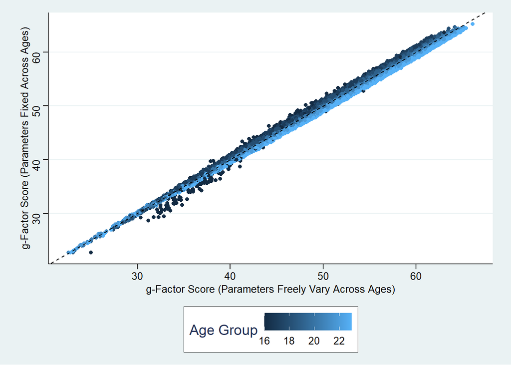

```r
invariant_scores_df <- estimate_factor_scores(df, local_sem_invariant$parameters, moderator.grid, first_order_factors, items)

joint_scores_df <- merge(free_scores_df, invariant_scores_df, by = c("case_id", "age_group"), suffixes = c("_free", "_invariant"))

ggplot(joint_scores_df, aes(x = g_factor_score_free, y = g_factor_score_invariant, col = age_group))+
  geom_point()+
  geom_abline(slope = 1, intercept = 0, linetype = 'dashed')+
  labs(x = "g-Factor Score (Parameters Freely Vary Across Ages)", y = "g-Factor Score (Parameters Fixed Across Ages)")+
  scale_color_continuous("Age Group")+
  theme_stata()
```